# COVID

**CARGA DIARIA**

**Esta es una versión preliminar del reporte, estamos trabajando en una versión interactiva y pensada en distintos dispositivos que publicaremos pronto en nuestro sitio**

Los siguientes análisis abordan las **compras realizadas durante 2020 que están relacionadas con la emergencia sanitaria COVID-19**, el objetivo es conocer el comportamiento de este tipo de adquisiciones, indagando sobre los principales compradores, proveedores y productos comprados para enfrentar la crisis.

Para establecer si una compra fue hecha para enfrentar la emergencia, **buscamos en sus descriptores indicios que nos permitan determinar este vínculo**, pero este trabajo se establece sobre el supuesto de que dichos indicios existen, cuestión que no siempre es así, por ello invitamos a las autoridades a cargo de la coordinación de esta crisis, a que instuyan a los diferentes organismos del Estado a generar las **marcas que permitan identificar las compras correspondientes**

`Definición Inicial: Se considera compra relacionada con la emergencia sanitaria (CORONAVIRUS) aquellas adquisciones cuyas descripcion o nombre de la orden de compra (OC) contengan las palabras "CORONA + VIRUS" + o "COVID".`

|  | Información del Proceso | Valor |
| --- | --- | --- |
| 1 | Fecha de última carga | 11-05-2020 |
| 2 | Fecha de última OC de COVID-19 enviada | 11-05-2020 |
| 3 | Cantidad OC COVID-19 desde 01-01-2020 | 15.972 |
| 4 | Monto Total de OCs de COVID-19 | 176.443 millones de pesos |

Antes de pasar a los análisis específicos te presentamos algunos datos estadísticos generales para conocer el comportamiento y avance de las compras realizadas por el Estado para enfrentar la pandemia (siempre que cumplan con la definición inicial)

|  | Item | Fecha | Cantidad de OC | Monto millones de $ |
| --- | --- | --- | --- | --- |
| 1 | Último día en que se hicieron compras de COVID-19 | 11-05-2020 | 266 | 1.917 |
| 2 | Día en que se ha comprado el mayor monto | 13-03-2020 | 44 | 12.861 |
| 3 | Primer día en que se realizó una compra COVID-19 | 14-01-2020 | 1 | 0 |
| 4 | Promedio de compras diario (OC y Monto) | 95.0 días | 168 | 1.857 |

## Principales órdenes de compra a la fecha

La siguiente tabla presenta las 10 órdenes de compra relacionadas a la emergencia, de acuerdo a la **definición inicial** y que se hayan realizado entre el **01-01-2020 y la fecha de carga**, ordenadas desde el mayor al menor monto.

|  | codigoOC | Fecha Envio | modalidad | Servicio | Proveedor | Monto en millones |
| --- | --- | --- | --- | --- | --- | --- |
| 1 | 1082417-11-SE20 | 13-03-2020 | Trato Directo | Subsecretaría De Salud Pública | Comercial Kendall Chile Ltda | 11.550 |
| 2 | 1079394-60-SE20 | 19-03-2020 | Trato Directo | Subsecretaría De Salud Pública | Bioquimica.Cl S.A. | 7.500 |
| 3 | 1082417-13-CM20 | 16-03-2020 | Convenio Marco | Subsecretaría De Salud Pública | Arquimed Innovación Spa | 4.450 |
| 4 | 1082417-37-SE20 | 23-03-2020 | Trato Directo | Subsecretaría De Salud Pública | Andover Alianza Médica S. A. | 3.088 |
| 5 | 1082417-43-CM20 | 27-03-2020 | Convenio Marco | Subsecretaría De Salud Pública | Dispositivos Médicos S.P.A | 2.518 |
| 6 | 1082417-42-SE20 | 27-03-2020 | Trato Directo | Subsecretaría De Salud Pública | Hemisferio Sur Sa | 2.138 |
| 7 | 1057918-39-SE20 | 23-04-2020 | Trato Directo | Servicio De Salud Ohiggins | Imedica Del Pacifico Ltda. | 1.835 |
| 8 | 1082417-26-CM20 | 18-03-2020 | Convenio Marco | Subsecretaría De Salud Pública | Arquimed Innovación Spa | 1.606 |
| 9 | 1082417-18-CM20 | 16-03-2020 | Convenio Marco | Subsecretaría De Salud Pública | Stryker Corporation Chile Y Compania Ltda | 1.593 |
| 10 | 1079394-86-SE20 | 30-03-2020 | Trato Directo | Subsecretaría De Salud Pública | Life Technologies Chile Spa | 1.448 |

## Principales Compradores

La siguiente tabla presenta los principales compradores que cumplen con la **definición inicial** y que hayan realizado compras de este tipo entre el **01-01-2020 y la fecha de carga**, la columna monto en millones corresponde a la suma total del monto de las órdenes de compras relacionadas a la emergencia que fueron adquiridas por el servicio, mientras que el porcentaje corresponde a la fracción que representa ese total de compras del servicio, sobre el total de adquisiciones relacionadas con la emergencia sanitaria

|  | Servicio | porcentaje | Monto en millones |
| --- | --- | --- | --- |
| 1 | Subsecretaría De Salud Pública | 36.5 | 64.338 |
| 2 | Servicio De Salud Nuble | 3.6 | 6.299 |
| 3 | Complejo Asistencial Dr. Victor Ríos Ruíz | 2.4 | 4.200 |
| 4 | Servicio De Salud Ohiggins | 2.0 | 3.536 |
| 5 | Servicio De Salud Araucanía Sur | 1.9 | 3.353 |
| 6 | Hospital De Puerto Montt | 1.9 | 3.297 |
| 7 | Hospital Regional De Antofagasta | 1.8 | 3.214 |
| 8 | Servicio De Salud Antofagasta | 1.8 | 3.210 |
| 9 | Hospital Doctor Hernán Henríquez Aravena | 1.8 | 3.091 |
| 10 | Servicio De Salud Del Reloncaví | 1.5 | 2.667 |

## Principales Proveedores a la fecha

La siguiente tabla presenta los principales proveedores que cumplen con la **definición inicial** y que hayan realizado ventas de este tipo entre el **01-01-2020 y la fecha de carga**, la columna monto en millones corresponde a la suma total del monto de las órdenes de compras relacionadas a la emergencia que fueron emitidas al proveedor, mientras que el porcentaje corresponde a la fracción que representa ese total de ventas del proveedor, sobre el total de adquisiciones relacionadas con la emergencia sanitaria.

|  | Proveedor | RUT Proveedor | Monto en millones | porcentaje |
| --- | --- | --- | --- | --- |
| 1 | Comercial Kendall Chile Ltda | 77.237.150-0 | 11.932 | 6.8 |
| 2 | Bioquimica.Cl S.A. | 76.563.320-6 | 7.651 | 4.3 |
| 3 | Arquimed Innovación Spa | 76.560.564-4 | 7.610 | 4.3 |
| 4 | Life Technologies Chile Spa | 77.453.910-7 | 5.653 | 3.2 |
| 5 | Andover Alianza Médica S. A. | 96.625.550-1 | 4.866 | 2.8 |
| 6 | Hemisferio Sur Sa | 96.533.330-4 | 4.267 | 2.4 |
| 7 | Imp. Dist. Arquimed Ltda. | 92.999.000-5 | 3.859 | 2.2 |
| 8 | Roche Chile Ltda. Roche Pharma | 82.999.400-3 | 3.374 | 1.9 |
| 9 | Imedica Del Pacifico Ltda. | 89.618.500-4 | 3.243 | 1.8 |
| 10 | Bluemedical Ltda. | 76.116.604-2 | 3.017 | 1.7 |

## Modalidad de Compra

El siguiente corresponde al análisis del comportamiento de la modalidad de compra según día, y respondiendo siempre a la **definición inicial** y que se hayan realizado entre el **01-01-2020 y la fecha de carga**.

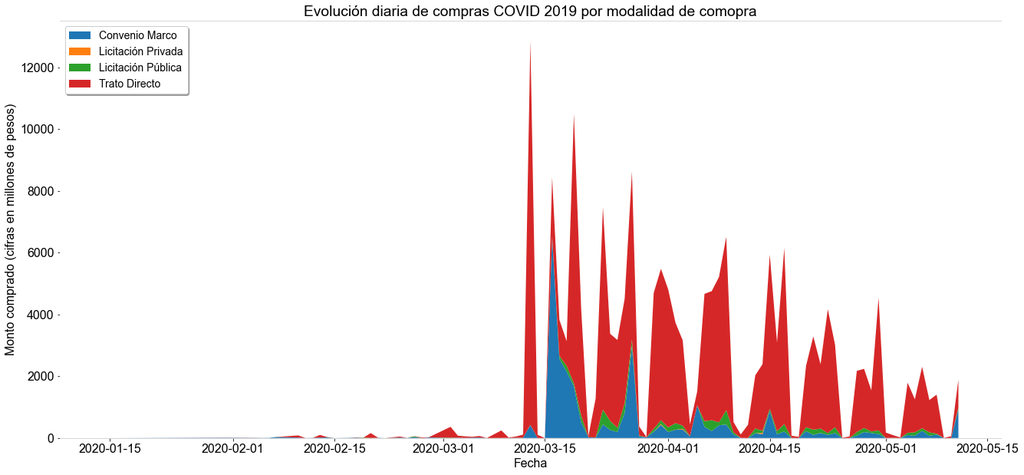

## Principales productos

La siguiente tabla presenta las compras que cumplan con la **definición inicial** y que se hayan realizado entre el **01-01-2020 y la fecha de carga**, mostrando los productos que más se compraron, sus respectivos montos y el procentaje que representan sobre el total de compras de COVID-19. Los productos son el nivel más desagregado de categorías de productos de acuerdo a la clasificación ONU de productos. La tabla presenta los diez principales.

|  | Producto | Monto en millones | porcentaje |
| --- | --- | --- | --- |
| 1 | Mascarillas de aislamiento o quirófano para el... | 23.486 | 13.3 |
| 2 | Circuito de respiración o ventilador | 19.108 | 10.8 |
| 3 | Unidades de monitorización de flujo sanguíneo ... | 10.682 | 6.1 |
| 4 | Ventiladores de cuidado intensivo pediátrico o... | 8.431 | 4.8 |
| 5 | Kits de ensayo parasitológicos o micológicos, ... | 7.694 | 4.4 |
| 6 | Kits de ensayo de banco de sangre o suministros | 6.630 | 3.8 |
| 7 | Camillas de paciente o accesorios de camilla | 5.438 | 3.1 |
| 8 | Equipo para protección | 4.942 | 2.8 |
| 9 | Reactivos, soluciones o tinturas microbiológic... | 3.412 | 1.9 |
| 10 | Kits de exámenes rápidos | 3.319 | 1.9 |

### Gráfico de principales productos comprados para COVID, con sus respectivos compradores y proveedores

El siguiente gráfico presenta los 5 principales productos comprados que cumplan con la **definición inicial** y que se hayan realizado entre el **01-01-2020 y la fecha de carga**, junto los principales compradores y proveedores, estos últimos de definieron enbase al monto de la transacción, solo se consideraron principales aquellas transaccione sobre los 100 millones de pesos. El gráfico permite ver las relaciones Comprador -> Productos -> Proveedor

[interactive chart not shown]